# Women Employment Status

Denise Bishevsky

2021-07-18

[figure not shown]

# Introduction

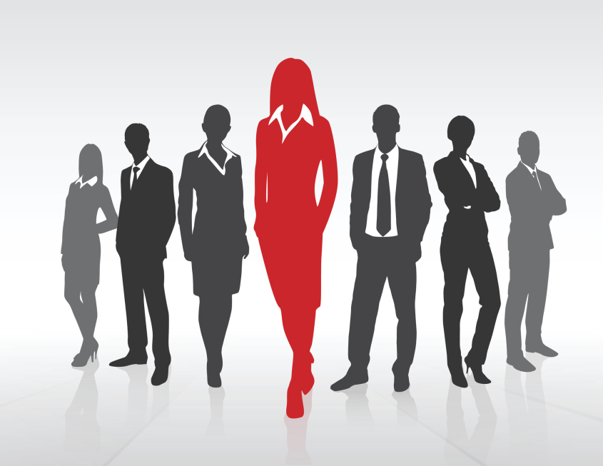

### Information about the data:

- This data set was taken from [Tidytuesday](https://github.com/rfordatascience/tidytuesday/blob/master/data/2021/2021-02-23/readme.md).
- The data contains information about employed persons by industry, sex, race, and occupation.

### Goals:

As an engineering and management student and woman who will soon enter the job market I was interested in raising my awareness of the current market situation. So I decided to focus on answering the following questions:

- What are the income gaps between women and men?
- How has Covid-19 affected the various industries?
- What is the percentage of women in management positions and in what industries?
- And is it possible to build a model that predicts the earn of each person according to his data?

# Data Exploration and Tidying

```r
# Import Libraries
library(tidyverse)
library(scales)
library(gridExtra)
library(ggbump)
library(ggplot2)
library(ggpubr)
library(dplyr)
library(hrbrthemes)
library(cowplot)
library(forcats)
library(reshape2)
library(extrafont)
```

```r
# I will use this theme for the graphs later on
costum_theme <- function() {
  theme(
    axis.text = element_text(colour = "#555555", family = "Montserrat"),
    plot.title = element_text(colour = "#271729", size = 18, vjust = 1,hjust = 0.5, family = "Montserrat"),
    plot.subtitle = element_text(hjust = 0.5, margin = unit(c(0,0,0,1), "cm")),
    axis.title = element_text(colour = "#271729", size = 13, family = "Montserrat"),
    panel.grid.major.x = element_line(colour = "#e4e4e4"),
    panel.grid.minor.x = element_line(colour = "#e4e4e4"),
    panel.grid.major.y = element_line(colour = "#e4e4e4"),
    panel.grid.minor.y = element_line(colour = "#e4e4e4"),
    strip.text = element_text(family = "Montserrat", colour = "white"),
    strip.background = element_rect(fill = "#271729"),
    axis.ticks = element_line(colour = "#271729")

  )
}
```

```r
# Import Data
employed <- readr::read_csv('https://raw.githubusercontent.com/rfordatascience/tidytuesday/master/data/2021/2021-02-23/employed.csv')
earn <- readr::read_csv('https://raw.githubusercontent.com/rfordatascience/tidytuesday/master/data/2021/2021-02-23/earn.csv')
```

First, we will get to know the data we have by looking at its columns and variables:

Here is the data dictionary:

#### employed.csv

| variable | class | description |
| --- | --- | --- |
| industry | character | Industry group |
| major_occupation | character | Major Occupation category |
| minor_occupation | character | Minor Occupation Categoru |
| race_gender | character | Race or gender group (total, men/women, race) |
| industry_total | double | Industry total |
| employ_n | double | Employed number |
| year | integer | Year |

#### earn.csv

| variable | class | description |
| --- | --- | --- |
| sex | character | Gender |
| race | character | Racial group |
| ethnic_origin | character | Ethnic origin (hispanic or non-hispanic) |
| age | character | Age group |
| year | integer | Year |
| quarter | integer | Quarter |
| n_persons | double | Number of persons employed by group |
| median_weekly_earn | integer | Median weekly earning in current dollars |

I will start by exploring the `"employed"` data set:

```r
glimpse(employed)
```

```
Rows: 8,184
Columns: 7
$ industry         <chr> "Agriculture and related", "Agriculture and related",~
$ major_occupation <chr> "Management, professional, and related occupations", ~
$ minor_occupation <chr> "Management, business, and financial operations occup~
$ race_gender      <chr> "TOTAL", "TOTAL", "TOTAL", "TOTAL", "TOTAL", "TOTAL",~
$ industry_total   <dbl> 2349000, 2349000, 2349000, 2349000, 2349000, 2349000,~
$ employ_n         <dbl> 961000, 58000, 13000, 94000, 12000, 96000, 931000, 10~
$ year             <dbl> 2020, 2020, 2020, 2020, 2020, 2020, 2020, 2020, 2020,~
```

Let’s look at what years this data refers to:

```r
min(employed$year)
```

```
[1] 2015
```

```r
max(employed$year)
```

```
[1] 2020
```

The data set contains information on the years 2015-2020.

Let’s check which industries are in the data:

```r
employed %>%
  count(industry, sort = TRUE)
```

```
# A tibble: 26 x 2
   industry                          n
   <chr>                         <int>
 1 Agriculture and related         396
 2 Construction                    396
 3 Durable goods                   396
 4 Education and health services   396
 5 Financial activities            396
 6 Information                     396
 7 Leisure and hospitality         396
 8 Manufacturing                   396
 9 Nondurable goods                396
10 Other services                  396
# ... with 16 more rows
```

As we can see, In this data set we have 26 industry types.

I noticed that we have a column that contains two categories, let’s take a closer look at this:

```r
employed %>%
  count(race_gender, sort = TRUE)
```

```
# A tibble: 6 x 2
  race_gender                   n
  <chr>                     <int>
1 Black or African American  1386
2 Men                        1386
3 TOTAL                      1386
4 White                      1386
5 Women                      1386
6 Asian                      1254
```

I would like to brake down the “race_gender” column as it might have overlapping groups.  
This way I can treat each category more conveniently later on:

```r
# Create new column called "category"
employed<-employed %>%
  mutate(category = case_when(
    race_gender == "TOTAL" ~ "Total",
    race_gender %in% c("Men", "Women") ~ "Sex",
    # other cases will be called "Race"
    TRUE ~ "Race"
  ))
```

Let’s take a look at “major_occupation” and “minor_occupation” columns:

```r
employed %>%
  count(major_occupation)
```

```
# A tibble: 5 x 2
  major_occupation                                                 n
  <chr>                                                        <int>
1 Management, professional, and related occupations             1488
2 Natural resources, construction, and maintenance occupations  2232
3 Production, transportation, and material moving occupations   1488
4 Sales and office occupations                                  1488
5 Service occupations                                           1488
```

```r
employed %>%
  count(minor_occupation)
```

```
# A tibble: 12 x 2
   minor_occupation                                                n
   <chr>                                                       <int>
 1 Construction and extraction occupations                       744
 2 Farming, fishing, and forestry occupations                    744
 3 Installation, maintenance, and repair occupations             744
 4 Manage-ment, business, and financial operations occupations   124
 5 Management, business, and financial operations occupations    620
 6 Office and administrative support occupations                 744
 7 Production occupations                                        744
 8 Professional and related occupations                          744
 9 Protective service occupations                                744
10 Sales and related occupations                                 744
11 Service occupations, except protective                        744
12 Transportation and material moving occupations                744
```

Apparently there is a typo in line number 4 in “minor_occupation” output.  
What they intended to name it was probably “Management, business, and financial operations occupation”, like in line 5 and not “`Manage-ment`, business, and financial operations occupations”.

So Let’s fix it:

```r
employed$minor_occupation[employed$minor_occupation == "Manage-ment, business, and financial operations occupations"] <-
  "Management, business, and financial operations occupations"
employed %>%
  count(minor_occupation)
```

```
# A tibble: 11 x 2
   minor_occupation                                               n
   <chr>                                                      <int>
 1 Construction and extraction occupations                      744
 2 Farming, fishing, and forestry occupations                   744
 3 Installation, maintenance, and repair occupations            744
 4 Management, business, and financial operations occupations   744
 5 Office and administrative support occupations                744
 6 Production occupations                                       744
 7 Professional and related occupations                         744
 8 Protective service occupations                               744
 9 Sales and related occupations                                744
10 Service occupations, except protective                       744
11 Transportation and material moving occupations               744
```

That is better!  
Done with “employed” data set, Let’s move on to `"earn"` data set.

```r
glimpse(earn)
```

```
Rows: 4,224
Columns: 8
$ sex                <chr> "Both Sexes", "Both Sexes", "Both Sexes", "Both Sex~
$ race               <chr> "All Races", "All Races", "All Races", "All Races",~
$ ethnic_origin      <chr> "All Origins", "All Origins", "All Origins", "All O~
$ age                <chr> "16 years and over", "16 years and over", "16 years~
$ year               <dbl> 2010, 2010, 2010, 2010, 2011, 2011, 2011, 2011, 201~
$ quarter            <dbl> 1, 2, 3, 4, 1, 2, 3, 4, 1, 2, 3, 4, 1, 2, 3, 4, 1, ~
$ n_persons          <dbl> 96821000, 99798000, 101385000, 100120000, 98329000,~
$ median_weekly_earn <dbl> 754, 740, 740, 752, 755, 753, 753, 764, 769, 771, 7~
```

As before, we will look at what years the data set refers to:

```r
min(earn$year)
```

```
[1] 2010
```

```r
max(earn$year)
```

```
[1] 2020
```

The data set contains information on the years 2010-2020.

Let’s see what is the ratio of men and women in this sample:

```r
earn %>%
  count(sex)
```

```
# A tibble: 3 x 2
  sex            n
  <chr>      <int>
1 Both Sexes  1408
2 Men         1408
3 Women       1408
```

There is equal representation of each sex.

I would also like to look at the column of ages:

```r
earn %>%
  count(age)
```

```
# A tibble: 12 x 2
   age                   n
   <chr>             <int>
 1 16 to 19 years      132
 2 16 to 24 years      660
 3 16 years and over   660
 4 20 to 24 years      132
 5 25 to 34 years      132
 6 25 to 54 years      660
 7 25 years and over   660
 8 35 to 44 years      132
 9 45 to 54 years      132
10 55 to 64 years      132
11 55 years and over   660
12 65 years and over   132
```

### Note

> In overall the data is quite tidy, however I noticed that the lines of each observation is relate to a large group of people who have the same variables. You can see the number of people in each group by column “n_persons” at the earn data set and “employ_n” at the employed data set.  
> I will take this into account when approaching the rest of the work.

# Transformation and Visualization

Let’s get down to business!  
In the previous chapter we saw that the `earn` table has a column named `median_weekly_earn.` To start, I would like to examine what is the difference between women’s and men’s median weekly earnings:

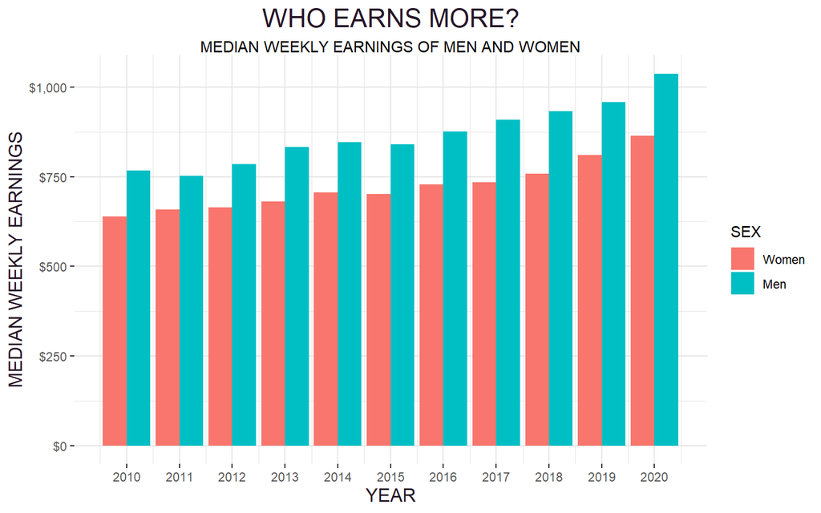

```r
# Draw histogram
weekly_earn_plot<- earn %>%
    group_by(year, sex) %>%
    filter(sex!="Both Sexes") %>%
  # calculate the median weekly earn across all the women and men groups
    summarise(median_earn = median(median_weekly_earn)) %>%
  #plot
    ggplot(aes(x=year, y= median_earn, fill=fct_rev(sex))) +
    geom_col(position="dodge", show.legend = T) +
    scale_color_manual(values=c("#3abcff","#ff7be5")) +
    scale_y_continuous(labels = dollar_format(prefix = "$"))+
    scale_x_continuous(breaks = pretty_breaks(10))+
    labs(y="MEDIAN WEEKLY EARNINGS",
         x= "YEAR",
         fill = "SEX",
         title=  "WHO EARNS MORE?",
         subtitle = "MEDIAN WEEKLY EARNINGS OF MEN AND WOMEN")+
  theme_minimal()
weekly_earn_plot + costum_theme()
```

We can clearly see a number of things:

- First, over the years the median weekly earnings of both sexes have increased quite linearly.
- It is noticeable that the median weekly earnings of men are higher than of women.

Let’s examine whether there are differences in the earnings between the sexes according to their ages:

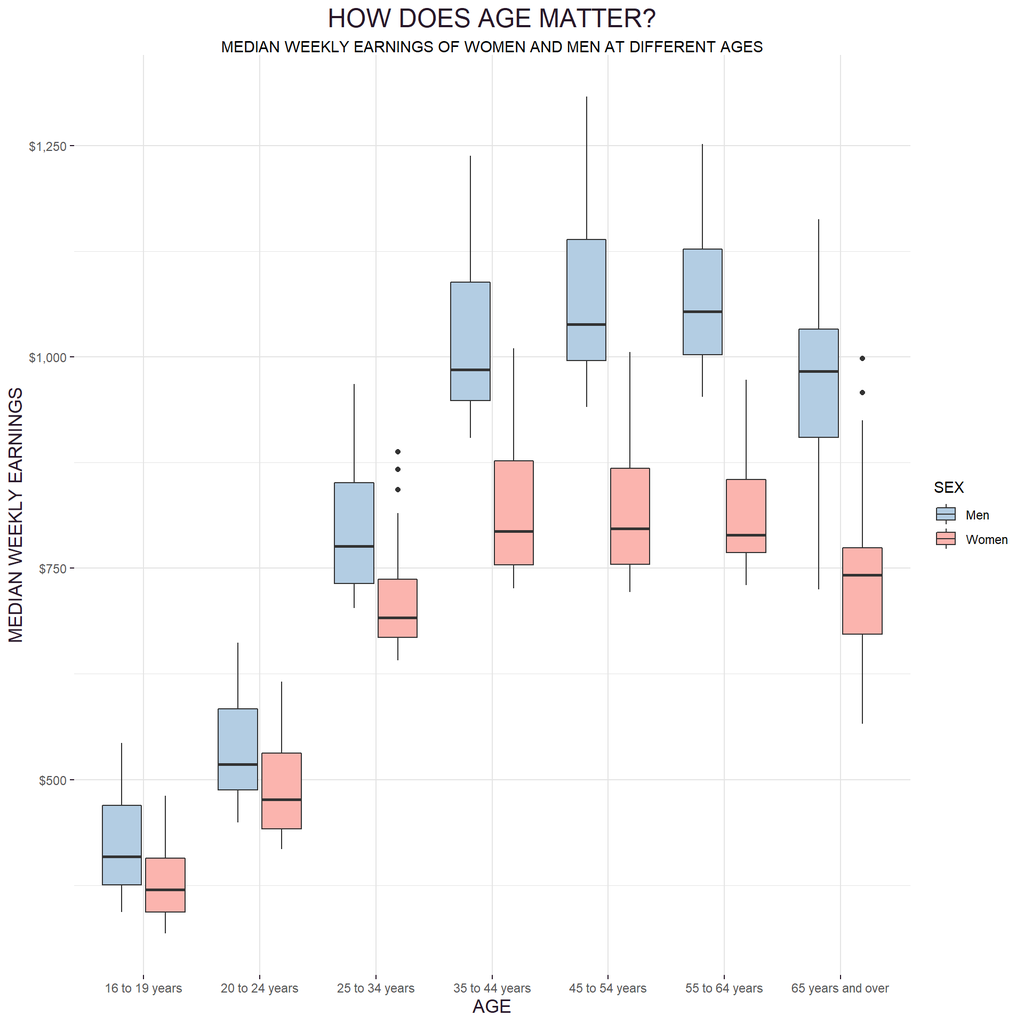

```r
# Select the ages that don't overlaping
age_to_plot <- c("16 to 19 years", "20 to 24 years","25 to 34 years",
                 "35 to 44 years","45 to 54 years","55 to 64 years","65 years and over")

# Create graph that shows the median weekly earn of women at different ages between 2010-2020
women_earn_by_age <- earn %>%
  group_by(sex, age) %>%
  filter(sex!="Both Sexes") %>%
  filter(age %in% age_to_plot) %>%
  ggplot(aes(x=age, y=median_weekly_earn , fill = sex)) +
  geom_boxplot()+
  scale_y_continuous(labels = dollar_format(prefix = "$"))+
  labs(y="MEDIAN WEEKLY EARNINGS", x= "AGE", fill = "SEX",
        title = "HOW DOES AGE MATTER?",
        subtitle = "MEDIAN WEEKLY EARNINGS OF WOMEN AND MEN AT DIFFERENT AGES")+
  scale_fill_manual(values=c('#b3cde3', '#fbb4ae'))+
  theme_minimal()
women_earn_by_age + costum_theme()
```

- In this graph we see the variance of the weekly median earnings of different groups of women and men separated by their ages and distributed by years.
- Up to the age of 35-44 the median weekly earnings of both sexes increased with a sharp positive slope. Men’s earnings continue to grow even until age 45-54. Thereafter, the earnings of both sexes remain stable and at age 65 and above it decreases.
- One can see that the median weekly earnings of women is always lower than that of men but the significant gap starts from the ages of 35-44.

Lets take a look at the industry popularity among men and women:

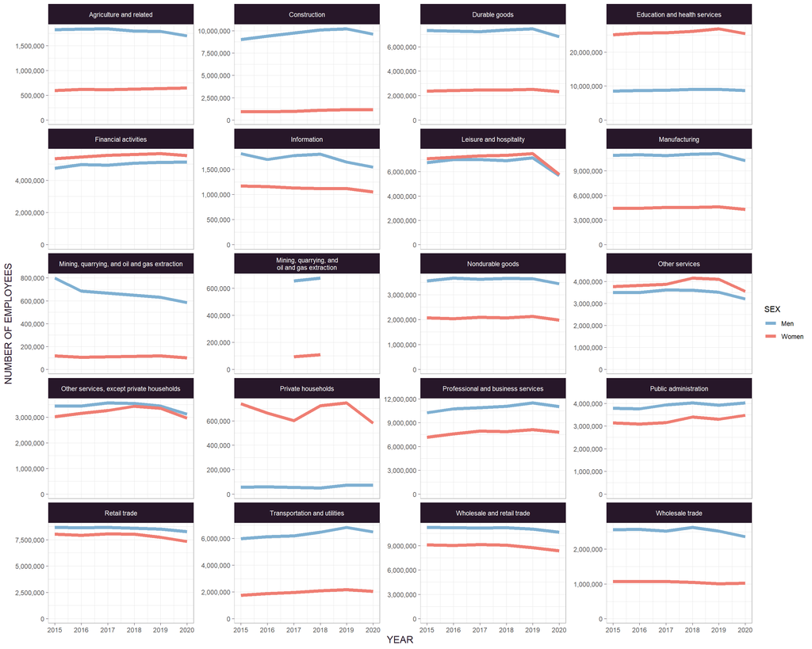

```r
# Draw an line graph for each industry
employees_amount<-employed %>%
  #filter and group
  filter(!is.na(employ_n)) %>%
  filter(category == "Sex") %>%
  group_by(year, race_gender, industry) %>%
  # calculate the number of employees in each industry
  summarize(employies = sum(employ_n)) %>%
  #plot
  ggplot(aes(x=year, y=employies, color = race_gender)) +
  guides(fill = guide_legend(reverse=T))+
  geom_line(size=2) +
  facet_wrap(~industry, scales = "free_y", ncol = 4) +
  expand_limits(y = 0) +
  scale_y_continuous(labels = comma) +
  labs(y = "NUMBER OF EMPLOYEES", x = "YEAR", color = "SEX", prob=TRUE,
     cex=5) +
  scale_x_continuous(breaks = pretty_breaks(5))+
  theme(
    strip.text.x = element_text(margin = margin(2, 0, 2, 0)),
    axis.text.x = element_text(angle = 90, vjust = 0.5, hjust=1))+
  scale_color_manual(values=c("#7FB0D2","#EF7E73"))+
  theme_light()
employees_amount +costum_theme()
```

- It can be seen that between the years 2019-2020 there is a decrease in the number of employees in most industries, probably in light of Covid-19. I would like to zoom in and see which industry was most affected and compare it between men and women.
- I also noticed that the industry “Mining, quarrying, and oil and gas extraction” does not contain full data so in the next part I will not use it.

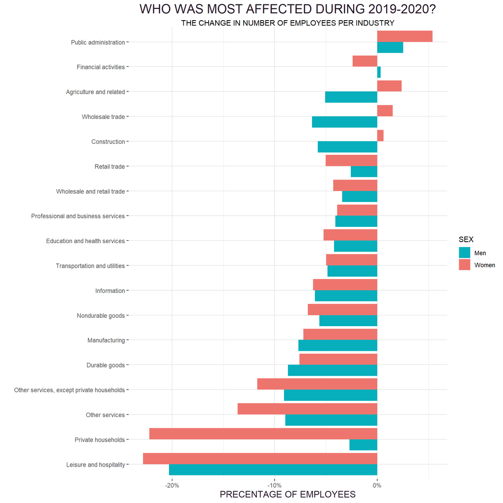

```r
# Draw a columns graph shows the change of number of employees in each industry
employed_2019_2020<- employed %>%
  filter(!is.na(employ_n),
         industry != "Mining, quarrying, and oil and gas extraction")%>%
  #reorder the industry column
  mutate(industry = fct_reorder(industry,employ_n, sum))%>%
  # focus only on 2020-2019
  filter(year %in% c(2019,2020)) %>%
  group_by(industry, year, race_gender, category) %>%
  # calculate the total number of employees
  summarise(employ_n = sum(employ_n))

employed_2019_2020 <- employed_2019_2020 %>%
  arrange(year) %>%
  group_by(industry, race_gender, category)%>%
  # calculate the ratio of employees that dropped or joined the industry
  summarize(ratio = last(employ_n)/first(employ_n),
            change = ratio - 1,
            employed_2019 = first(employ_n)) %>%
  ungroup()
#plot
employed_2019_2020<- employed_2019_2020  %>%
  filter(category == "Sex") %>%
  mutate(industry = fct_reorder(industry,change)) %>%
  ggplot(aes(change, industry, fill=race_gender)) +
  geom_col(position = "dodge") +
  scale_x_continuous(labels = percent)+
  labs(title = "WHO WAS MOST AFFECTED DURING 2019-2020?",
       subtitle = "THE CHANGE IN NUMBER OF EMPLOYEES PER INDUSTRY" ,
         x ="PRECENTAGE OF EMPLOYEES",
       y ="",
       fill = "SEX")+
  scale_fill_manual(values=c('#06AFBB', '#EE756E'))+
  theme_minimal()
employed_2019_2020 + costum_theme()
```

- In most industries the number of workers decreased but in some others they also increased!
- The industry most affected is “Leisure and hospitality” and that gets along with the fact that at the time of the lockdown this industry was not as active as usual.
- On the other hand, it is interesting to see that in “Public administration” the number of employees increased.
- “Private householders” seem to have a significant difference in the number of women leaving the industry compared to men, but from what can be seen in previous graph, there are far more women in this industry than men.

The next thing I would like to check is from the population of managers, what percentage of them are women:

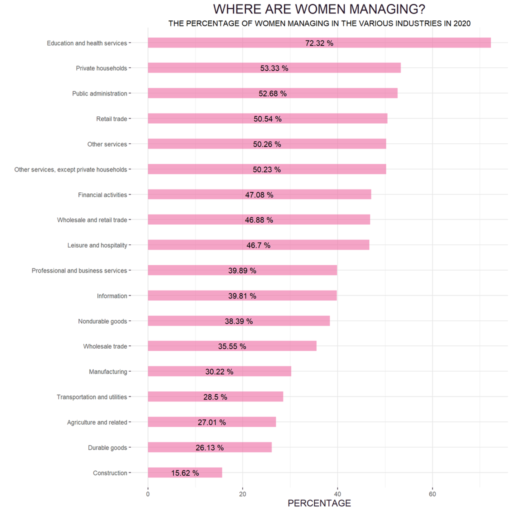

```r
# Draw bars graph show the percentage of women managing in the various industries in 2020
women_managers_2020 <- employed %>%
  filter(year == 2020) %>%
  filter(industry != "Mining, quarrying, and oil and gas extraction")%>%
  filter(!is.na(employ_n)) %>%
  filter(category == "Sex") %>%
  # choose only the managers
  filter(major_occupation == "Management, professional, and related occupations")%>%
  group_by(race_gender, industry) %>%
  summarize(employees = sum(employ_n))

women_managers_2020 <- women_managers_2020 %>%
   group_by(industry) %>%
  # create new column that contains the proportion of women that are managers in each industry
   mutate(Percentage = round((employees/sum(employees))*100, 2))%>%
  filter(race_gender == "Women")%>%
  arrange(Percentage)

#plot
women_managers_2020<- women_managers_2020 %>%
 ggplot(aes(x = reorder(industry,Percentage), y =Percentage))+
  geom_bar(stat="identity", fill="#EC68A0", alpha=.6, width=.4)+
  geom_text(aes(label = paste(Percentage,"%"), y = Percentage),
            position = position_stack(vjust = 0.5))+
  coord_flip()+
  labs(y="PERCENTAGE",
       x= "",
       title = "WHERE ARE WOMEN MANAGING?",
      subtitle = "THE PERCENTAGE OF WOMEN MANAGING IN THE VARIOUS INDUSTRIES IN 2020")+
  theme_minimal()
women_managers_2020 + costum_theme()
```

- In the “Education and health services” industry it seems that most managers are women, and alternatively in the “Construction” industry most managers are men.

# Statistical Hypothesis Testing

### Two-Sample Proportions Test

Continuing from the last graph, I would like to check if the proportion of women holding managerial positions is equal to that of men.
To do this, I will create a comparison table between the number of women and men in managerial and non-managerial positions and run a two- sample proportion test. This hypothesis test will help to check whether the proportions in the two groups are equal.
Let:
$$P_1 = \text{The proportion of women who are managers}$$
$$P_2 = \text{The proportion of men who are managers}$$
That is, our hypotheses will be:

$$H_0 : P_1 - P_2 = 0$$
$$H_1 : P_1 - P_2 \neq 0$$

```r
employees_2020 <- employed %>%
  filter(year == 2020) %>%
  filter(industry != "Mining, quarrying, and oil and gas extraction")%>%
  filter(!is.na(employ_n)) %>%
  filter(category == "Sex") %>%
  group_by(race_gender, major_occupation) %>%
  summarize(employees = sum(employ_n))

# calculate amount of men that are managers-------------------------------------
df <- employees_2020 %>%
  filter(major_occupation == "Management, professional, and related occupations",
         race_gender == "Men")

men_managers<- sum(df$employees)
#---------------------------------------------------------------------------------

# calculate amount of women that are managers
df <- employees_2020 %>%
  filter(major_occupation == "Management, professional, and related occupations",
         race_gender == "Women")

women_managers<- sum(df$employees)
#---------------------------------------------------------------------------------
# calculate amount of men that are not managers
df <- employees_2020 %>%
  filter(major_occupation != "Management, professional, and related occupations",
         race_gender == "Men")

men_not_managers<- sum(df$employees)
#-------------------------------------------------------------------------------
# calculate amount of women that are not managers
df <- employees_2020 %>%
  filter(major_occupation != "Management, professional, and related occupations",
         race_gender == "Women")

women_not_managers<- sum(df$employees)
#-------------------------------------------------------------------------------

# create a table
managers_2020<- matrix(c(women_managers, women_not_managers, men_managers, men_not_managers), ncol = 2, byrow = T)
rownames(managers_2020) <- c("WOMEN","MEN")
colnames(managers_2020) <- c("MANAGERS", "NOT MANAGERS")
managers_2020 = as.table(managers_2020)
managers_2020
```

```
      MANAGERS NOT MANAGERS
WOMEN 36599000     48734000
MEN   36468000     65597000
```

Now we are all set and can run the proportionality test:

```r
prop.test(managers_2020, alternative = "two.sided")
```

```
    2-sample test for equality of proportions with continuity correction

data:  managers_2020
X-squared = 1001458, df = 1, p-value < 2.2e-16
alternative hypothesis: two.sided
95 percent confidence interval:
 0.07145423 0.07173475
sample estimates:
   prop 1    prop 2
0.4288962 0.3573017
```

- As can be seen, at a confidence level of 95 percent, the p-value is less than the significance level of 0.05 therefore we will reject the null hypothesis. In other words, it turns out that in 2020 the proportion of women holding managerial positions was greater than that of men and it can be seen that it was 42% compared to 35%.

To illustrate this visually I will draw a graph:

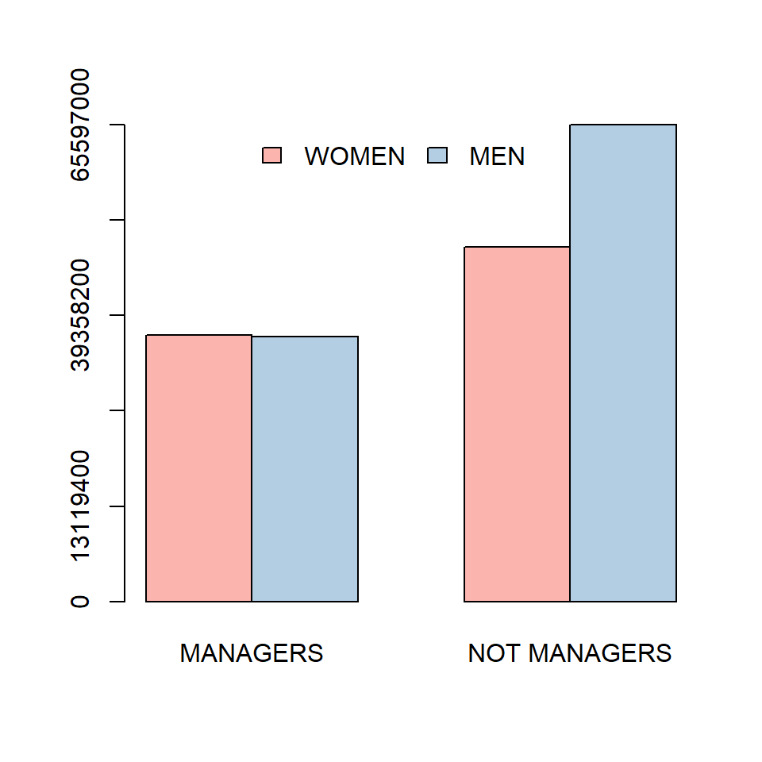

```r
# Draw barplot that shows the difference between the amount of
# men and women in management and non- management professions
colors <- c('#fbb4ae', '#b3cde3')
barplot(managers_2020,
        beside = TRUE,
        col= colors,
        legend = TRUE,
        args.legend = list(bty = "n", x = "top", ncol = 2),
        yaxp=c(0, max(managers_2020), 5))
```

- In this case it can be seen quite clearly that indeed the proportion of women holding managerial positions compared to man is greater.

# Modeling

I would like to build a model that will predict the median weekly earnings of each person. To do this I use a `linear regression` model.

At the beginning of our journey we saw that as the years go by, the median weekly earnings increases and so, for starters, I will try to predict it using the `"year"` column.

```r
# Clear the data set from "Both Sexes" variable
earn_for_model <- earn %>%
  filter(age %in% age_to_plot,
         sex != "Both Sexes")

linear_model_1 <- lm(median_weekly_earn ~year, data = earn_for_model,weights = n_persons)
summary(linear_model_1)
```

```
Call:
lm(formula = median_weekly_earn ~ year, data = earn_for_model,
    weights = n_persons)

Weighted Residuals:
    Min      1Q  Median      3Q     Max
-823689 -376167 -169681  160523 1209005

Coefficients:
              Estimate Std. Error t value Pr(>|t|)
(Intercept) -44563.896   4425.202  -10.07   <2e-16 ***
year            22.542      2.196   10.27   <2e-16 ***
---
Signif. codes:  0 '***' 0.001 '**' 0.01 '*' 0.05 '.' 0.1 ' ' 1

Residual standard error: 476300 on 614 degrees of freedom
Multiple R-squared:  0.1465,    Adjusted R-squared:  0.1451
F-statistic: 105.4 on 1 and 614 DF,  p-value: < 2.2e-16
```

- As you it can be seen the results of the model are not amazing.
- The model is significant as it’s p-value is less than the significance level, but its R-squared and Adjusted R-squared are very low.  
  We will draw a graph that illustrates why this happened:

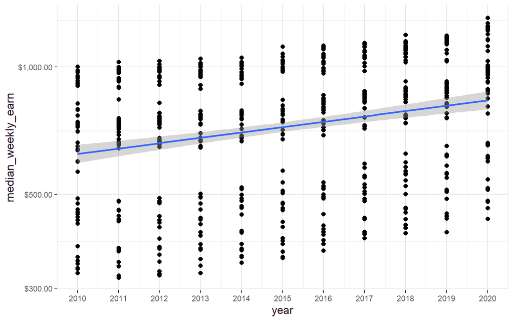

```r
earn_for_model %>%
  ggplot(aes(y=median_weekly_earn, x= year))+
  geom_point(size = 2)+
  scale_y_log10(labels = dollar_format(prefix = "$"))+
  stat_smooth(method = "lm")+
  scale_x_continuous(breaks = pretty_breaks(10))+
  theme_minimal()+
  costum_theme()
```

- The graph does justify the fact that the model we built requires improvement. You can see that the points are scattered in a way that looks like groups. This means that more explanatory variables need to be added to the model to get better results.

In the graphs we drew in the visualization section we saw that there is a relationship between `sex`, `age` and the median weekly earnings  
It’s time to add them to the model:

> Note that in the next model uses naive addition of explanatory variables to the model, assuming all variables are independent. I will expand on that later.

```r
linear_model_2 <- lm(median_weekly_earn ~ age + sex + year, data = earn_for_model, weights = n_persons)

summary(linear_model_2)
```

```
Call:
lm(formula = median_weekly_earn ~ age + sex + year, data = earn_for_model,
    weights = n_persons)

Weighted Residuals:
    Min      1Q  Median      3Q     Max
-343013  -88545   -8056   94146  565656

Coefficients:
                       Estimate Std. Error t value Pr(>|t|)
(Intercept)          -4.606e+04  1.279e+03 -36.027  < 2e-16 ***
age20 to 24 years     1.195e+02  2.023e+01   5.908 5.78e-09 ***
age25 to 34 years     3.615e+02  1.935e+01  18.685  < 2e-16 ***
age35 to 44 years     5.372e+02  1.937e+01  27.729  < 2e-16 ***
age45 to 54 years     5.588e+02  1.937e+01  28.847  < 2e-16 ***
age55 to 64 years     5.608e+02  1.955e+01  28.684  < 2e-16 ***
age65 years and over  4.720e+02  2.163e+01  21.820  < 2e-16 ***
sexWomen             -1.804e+02  4.010e+00 -44.995  < 2e-16 ***
year                  2.310e+01  6.343e-01  36.410  < 2e-16 ***
---
Signif. codes:  0 '***' 0.001 '**' 0.01 '*' 0.05 '.' 0.1 ' ' 1

Residual standard error: 137500 on 607 degrees of freedom
Multiple R-squared:  0.9297,    Adjusted R-squared:  0.9288
F-statistic:  1004 on 8 and 607 DF,  p-value: < 2.2e-16
```

#### What a huge improvement!

- The R-squared increased to 0.9297 and the Adjusted R-squared to 0.9288
- In addition, it can be seen that the model and all its explanatory variables are significant.
- The estimators also behaves in the way that we expected them to behave - The base case is a man at the age of 16-19 and compare to him the older ages. The median weekly earnings rise until the age of 65 where it takes a slight dip. Also the earnings goes up over the years and finally if you are a woman your earnings are lower.

I will illustrate this also visually:

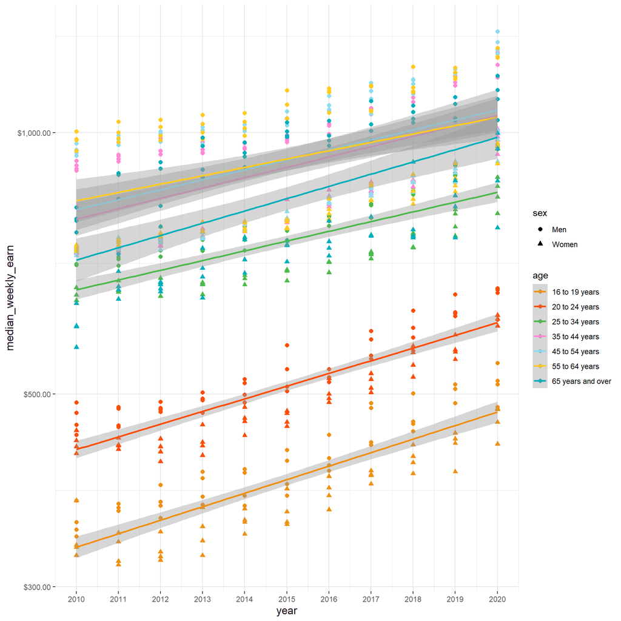

```r
colors <- c("#f8b365","#739fbe","#ef7e73","#bebada","#fbf4b5","#80beb3","#8ce5d4")

earn_for_model %>%
  ggplot(aes(y=median_weekly_earn, x= year,
             group=age,
             color = age))+
  geom_point(size = 2, aes(shape=sex))+
  scale_y_log10(labels = dollar_format(prefix = "$"))+
  stat_smooth(method = "lm")+
  scale_x_continuous(breaks = pretty_breaks(10))+
  scale_color_manual(values = c("#ef9014", "#FC4E07","#4dba4d","#ff88d5","#8edcef" ,"#FFCA22","#00AFBB"))+
  theme_minimal()+
  costum_theme()
```

#### But we can do better!

As I mentioned earlier, the latter model used a naive addition of explanatory variables to the model on the assumption that sex and age are independent variables. Although their addition has improved the model, it does not take into account that there are differences between women and men according to their age. To improve this we will add an interaction to the age-sex variables in the model:

```r
earn_for_model <- earn %>%
  filter(age %in% age_to_plot,
         sex != "Both Sexes")

linear_model_3 <- lm(median_weekly_earn ~ age*sex + year, data = earn_for_model, weights = n_persons)
summary(linear_model_3)
```

```
Call:
lm(formula = median_weekly_earn ~ age * sex + year, data = earn_for_model,
    weights = n_persons)

Weighted Residuals:
    Min      1Q  Median      3Q     Max
-224269  -48642   -4512   41728  459384

Coefficients:
                                Estimate Std. Error t value Pr(>|t|)
(Intercept)                   -4.597e+04  7.857e+02 -58.509  < 2e-16 ***
age20 to 24 years              1.147e+02  1.623e+01   7.070 4.32e-12 ***
age25 to 34 years              3.756e+02  1.548e+01  24.266  < 2e-16 ***
age35 to 44 years              6.012e+02  1.550e+01  38.795  < 2e-16 ***
age45 to 54 years              6.442e+02  1.551e+01  41.533  < 2e-16 ***
age55 to 64 years              6.536e+02  1.567e+01  41.704  < 2e-16 ***
age65 years and over           5.479e+02  1.739e+01  31.505  < 2e-16 ***
sexWomen                      -4.487e+01  2.365e+01  -1.897   0.0583 .
year                           2.302e+01  3.898e-01  59.067  < 2e-16 ***
age20 to 24 years:sexWomen     4.539e-01  2.525e+01   0.018   0.9857
age25 to 34 years:sexWomen    -4.090e+01  2.417e+01  -1.692   0.0912 .
age35 to 44 years:sexWomen    -1.555e+02  2.420e+01  -6.425 2.68e-10 ***
age45 to 54 years:sexWomen    -2.015e+02  2.419e+01  -8.327 5.60e-16 ***
age55 to 64 years:sexWomen    -2.167e+02  2.441e+01  -8.876  < 2e-16 ***
age65 years and over:sexWomen -1.823e+02  2.698e+01  -6.755 3.37e-11 ***
---
Signif. codes:  0 '***' 0.001 '**' 0.01 '*' 0.05 '.' 0.1 ' ' 1

Residual standard error: 84460 on 601 degrees of freedom
Multiple R-squared:  0.9737,    Adjusted R-squared:  0.9731
F-statistic:  1591 on 14 and 601 DF,  p-value: < 2.2e-16
```

Here is the graph of the final result:

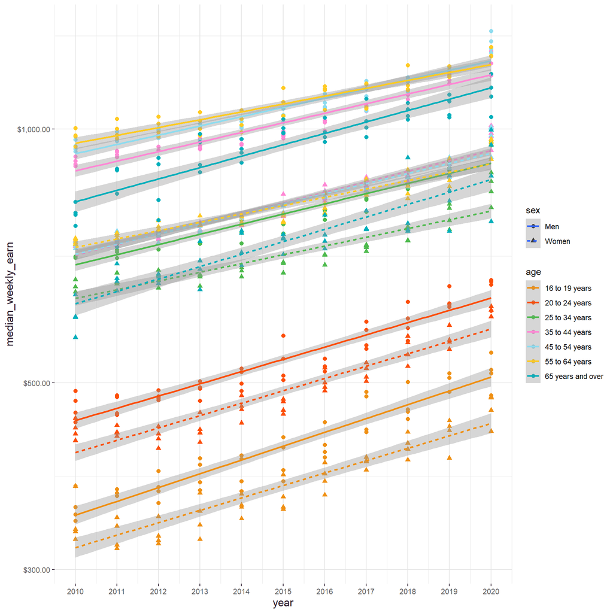

```r
colors <- c("#f8b365","#739fbe","#ef7e73","#bebada","#fbf4b5","#80beb3","#8ce5d4")

earn_for_model %>%
  ggplot(aes(y=median_weekly_earn, x= year,
             group=interaction(age, sex),
             color = age,
            linetype=sex))+
  geom_point(size = 2, aes(shape=sex))+
  scale_y_log10(labels = dollar_format(prefix = "$"))+
  stat_smooth(method = "lm")+
  scale_x_continuous(breaks = pretty_breaks(10))+
  scale_color_manual(values = c("#ef9014", "#FC4E07","#4dba4d","#ff88d5","#8edcef" ,"#FFCA22","#00AFBB"))+
  theme_minimal()+
  costum_theme()
```

Our model can now distinguish between 14 different groups. The straight lines show the profit of the men and the dashed lines the profit of the women. Also the colors divide the groups according to ages. This way you can easily see the profit differences of women and men according to their age and it fits with everything we talked about earlier.

Let’s take a look at the residuals and QQ plots:

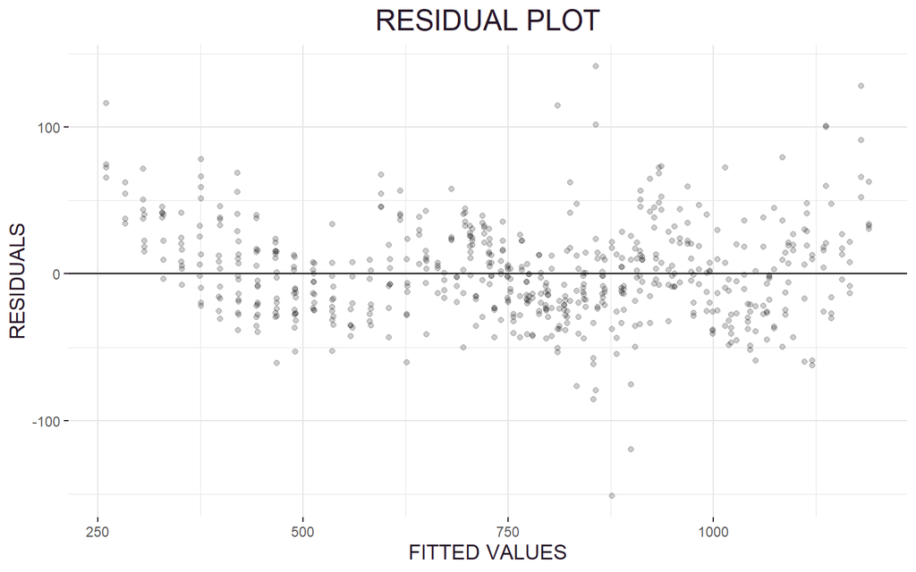

```r
resid_plot<- linear_model_3 %>% ggplot(aes(x=.fitted,y=.resid)) +
  geom_point(alpha=0.2) + geom_hline(yintercept=0) +
  labs(title="RESIDUAL PLOT", y="RESIDUALS", x= "FITTED VALUES")+
  theme_minimal()
resid_plot + costum_theme()
```

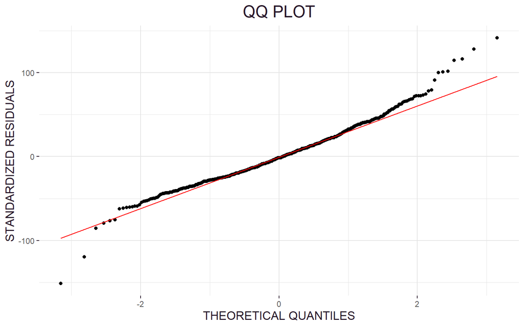

```r
resid_qq<- linear_model_3 %>% ggplot(aes(sample=.resid)) +
  geom_qq() + geom_qq_line(col="red") +
  labs(title="QQ PLOT", y="STANDARDIZED RESIDUALS", x= "THEORETICAL QUANTILES")+
  theme_minimal()
resid_qq+ costum_theme()
```

From these graphs we can conclude that:

- The residuals plot is looks homoscedastic.
- Although some points are not placed on the red line at the edges, most of them are indeed placed on this line and therefore a normal distribution can be assumed.

# Discussion and summary

We went through different techniques for manipulating and changing the data. We created different types of outputs like boxplot, histograms and more that allowed us to illustrate the questions we asked in a visually convenient way. We also used static tools to analyze the proportion of men and women in managerial positions and check if some variables are depended. Finally, we applied a linear regression model that makes it possible to predict what the median weekly earnings of each person will be by year, age and sex. Of course there are many more questions that can be asked about this data and by using the techniques and tools I have presented here it is possible to answer them.

I myself have learned new things. Although I knew there were differences between the salaries of men and women I did not know how significant they are. I was also surprised to find this in light of the fact that there are quite a number of women who hold managerial positions. Although there are quite a few reasons that have caused these differences I think awareness of the situation is already a good start to improve it. This project has definitely strengthened my awareness of the matter and I hope it will help me in the future.